# R Notebook

#EXERCICE 2:

Fonction à intégrer : Paramètres de chaques estimateurs (méthode, technique d’échantillonnage, nombre de points et tout ce que vous jugerez nécessaire)

##2.1 Création des différentes fonctions: ###2.1.0. Définition des fonctions communes:

```r
g_support = function(scal) { return( expm1(scal)/expm1(1) ) } ##exp()-1
MSE = function(vect_res)
{
  nbRep = length(vect_res)
  soluce = (exp(2)-3)/expm1(1)
  return( sum( (vect_res-soluce)**2)/nbRep )
}
```

###2.1.1 MC Noir/Blanc (NB):

```r
MC_NB = function(a, b, g_support, nb_points)
{
  maj = g_support(2) #Meilleur majorant: maj = g_support(2)
  x = runif(nb_points, a, b)
  y = runif(nb_points, 0, maj)

  n_success = sum( y < g_support(x) )
  return(maj * (b-a) * n_success/nb_points)
}
```

##Histogramme pour MC Noir/Blanc

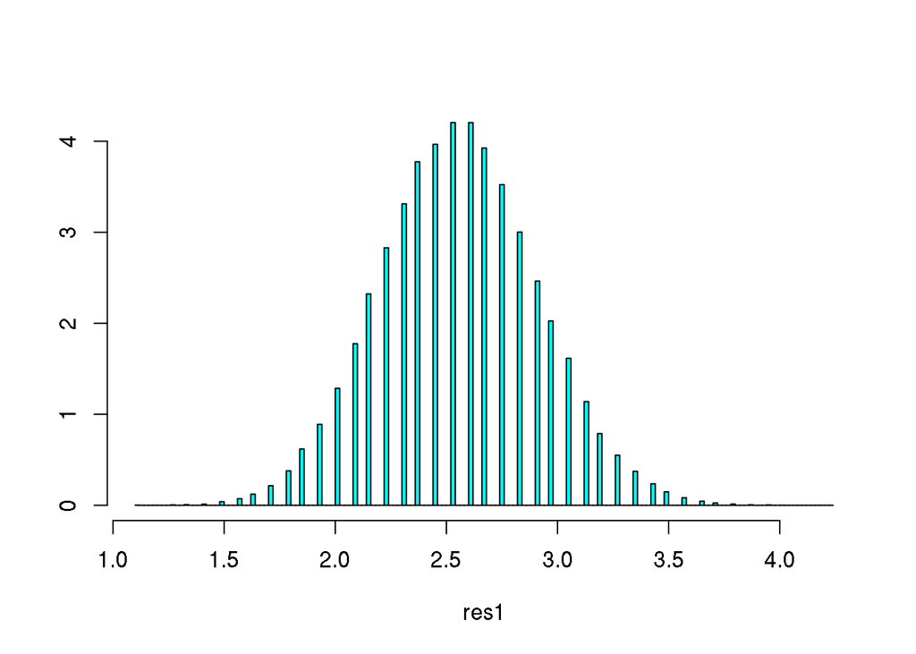

```r
library(MASS)
I <- (exp(2)-3)/(exp(1)-1)
nrep=100000
n=100
res1=rep(NA,nrep)

for (i in 1:nrep) {
  res1[i]=MC_NB(0,2,g_support,n)
}
mse1=(sum(res1-I)**2/nrep)
truehist(res1)
```

```r
mean(res1)
```

```
## [1] 2.554348
```

```r
var(res1)
```

```
## [1] 0.1257875
```

###2.1.2 MC avec densité auxiliaire SIMPLE (uniforme)

```r
MC_simple = function(a, b, g_support, nb_points)
{
  x_unif = runif(nb_points, a, b)
  return ( (b-a) * mean(g_support(x_unif)) )
}
```

##Histogramme MC simple

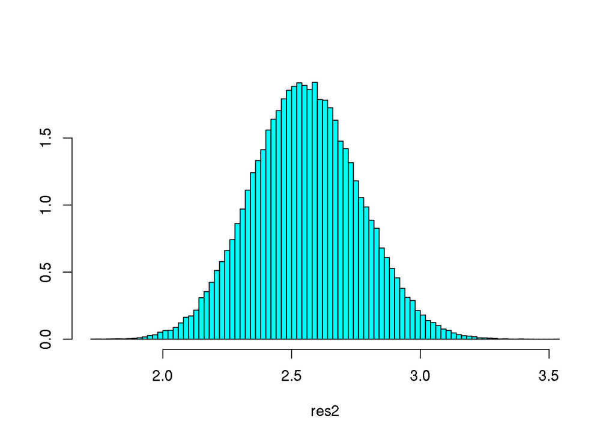

```r
nrep=100000
n=100
res2=rep(NA,nrep)

for (i in 1:nrep) {
  res2[i]=MC_simple(0,2,g_support,n)
}
mse2=(sum(res2-I)**2/nrep)
truehist(res2)
```

```r
mean(res2)
```

```
## [1] 2.554022
```

```r
var(res2)
```

```
## [1] 0.04343319
```

###2.1.3 MC avec densité auxiliaire en BETA:

```r
MC_beta = function(alpha, beta, k, nb_points, g_support)
{ #k pour [0, k]
  ech_beta = k * rbeta(nb_points, alpha, beta)
  f_beta = function(scal) { return( dbeta(scal/k, alpha, beta) ) }

  return ( k * mean(g_support(ech_beta)/f_beta(ech_beta)) )
}
```

##Histogramme MC Beta :

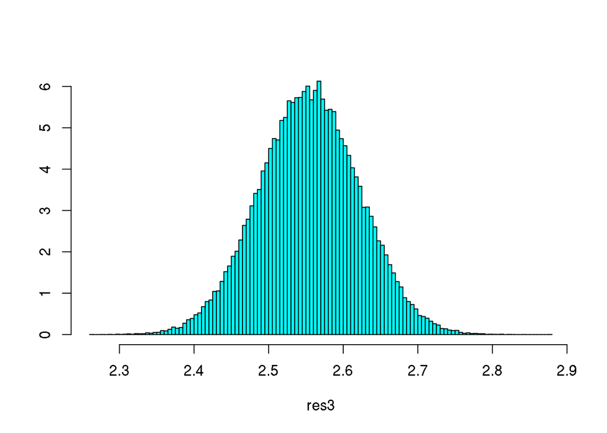

```r
nrep=100000
n=100
res3=rep(NA,nrep)

for (i in 1:nrep) {
  res3[i]=MC_beta(2,1,2 ,n,g_support)
}
mse3=(sum(res3-I)**2/nrep)
truehist(res3)
```

```r
mean(res3)
```

```
## [1] 2.554476
```

```r
var(res3)
```

```
## [1] 0.004516969
```

##2.2 Comparaisons et optimisations: ###2.2.1 Comparaison des 3 méthodes:

```r
nbRep = 10000
nb_points = 200
```

On commence par créer les vecteurs associés à chacune des 4 méthodes (NB, SIMPLE, BETA(alpha=2,beta=1) et BETA(alpha=1,beta=2)):

```r
vect_res_NB = rep(0, nbRep)
vect_res_SIMPLE = rep(0, nbRep)
vect_res_BETA_2_1 = rep(0, nbRep)
vect_res_BETA_1_2 = rep(0, nbRep)

for (i in 1:nbRep)
{
  vect_res_NB[i] = MC_NB(a=0, b=2, g_support, nb_points)
  vect_res_SIMPLE[i] = MC_simple(a=0, b=2, g_support, nb_points)
  vect_res_BETA_2_1[i] = MC_beta(alpha=2, beta=1, k=2, nb_points, g_support)
  vect_res_BETA_1_2[i] = MC_beta(alpha=1, beta=2, k=2, nb_points, g_support)
}
```

```r
print( paste( "MOY_NB =", mean(vect_res_NB), "| MSE_NB =", MSE(vect_res_NB) ) )
```

```
## [1] "MOY_NB = 2.55408035140486 | MSE_NB = 0.0633332568133959"
```

```r
print( paste( "MOY_SIMPLE =", mean(vect_res_SIMPLE),
              "| MSE_SIMPLE =", MSE(vect_res_SIMPLE) ) )
```

```
## [1] "MOY_SIMPLE = 2.55333549805185 | MSE_SIMPLE = 0.0211965948203704"
```

```r
print( paste( "MOY_BETA_2_1 =", mean(vect_res_BETA_2_1),
              "| MSE_BETA_2_1 =", MSE(vect_res_BETA_2_1) ) )
```

```
## [1] "MOY_BETA_2_1 = 2.55412682644076 | MSE_BETA_2_1 = 0.00224131106841179"
```

```r
print(paste("MOY_BETA_1_2 =", mean(vect_res_BETA_1_2),
            "| MSE_BETA_1_2 =", MSE(vect_res_BETA_1_2)  ) )
```

```
## [1] "MOY_BETA_1_2 = 2.54637364050043 | MSE_BETA_1_2 = 0.771492468243832"
```

Il est possible d’expliquer **qualitativement** les résultats des 3 méthodes MC par “échantillonnage”, en les classant par MSE et en affichant leurs densités de probabilité:

```r
graphics.off()
par(mfrow=c(1, 3))

curve(expm1(x)/expm1(1), from=0, to=2, xname="x",
          main="alpha=1 beta=2",
          xlab="alpha", ylab="beta")
curve(dbeta(x/2, 1, 2)/2, from=0, to=2, xname="x", add=T)

curve(expm1(x)/expm1(1), from=0, to=2, xname="x",
          main="UNIFORME",
          xlab="alpha", ylab="beta")
abline(a=1/2, b=0)

curve(expm1(x)/expm1(1), from=0, to=2, xname="x",
          main="alpha=2 beta=1",
          xlab="alpha", ylab="beta")
curve(dbeta(x/2, 2, 1)/2, from=0, to=2, xname="x", add=T)
```

[output not shown]

On a vu précédemment que sur ce type de méthodes par “importance variable” des valeurs, c’est la densité de probabilité de la variable auxiliaire qui détermine l’importance accordée à chaque valeur de l’intervalle support. De ce fait, plus la densité auxiliaire “mîme” fidèlement la densité de g (fonction de référence), plus on accorde une grande importance aux valeurs de g(x) les plus grandes, celles qui contribuent le plus à l’aire, meilleure sera l’approximation. Ainsi pour BETA_1_2, la densité auxiliaire s’oppose à la tendance de la densité de référence, accordant donc plus d’importance aux valeurs inférieures à 1, qui sont pourtant celles qui contribuent le moins à l’aire, puis que g est croissante sur [0, 2]. D’où son mauvais MSE. De même, avec sa densité de probabilité plate, la variable auxiliaire donne une importance équivalente à toutes les valeurs de l’intervalle, d’où son MSE intermédiaire C’est BETA_2_1 qui “épouse” le mieux g, d’où son MSE meilleur que les 2 autres.

On commence par créer une fonction de calcul du MSE adpatée aux fonctions de type Bêta:

```r
MSE_BETA = function(vect_param)
{
  my_alpha = vect_param[1] ; my_beta = vect_param[2]
  nbRep = 10000
  g_support = function(scal) { return( expm1(scal)/expm1(1) ) }

  vect_res = rep(0, nbRep)

  for (rep in 1:nbRep)
  {
    vect_res[rep] = MC_beta(alpha=my_alpha, beta=my_beta,
                            k=2, 200, g_support)
  }
  soluce = (exp(2)-3)/expm1(1)
  return( sum( (vect_res-soluce)**2)/nbRep )
}
```

Ensuite, on procède à un 1er quadrillage visuel grossier, pour rétrécir l’espace dans lequel on recherche les alpha et bêta optimaux:

```r
pas = 1
range_alpha = seq(pas, 5, by=pas)
range_beta = seq(pas, 3, by=pas)
long_alpha = length(range_alpha)
long_beta = length(range_beta)

graphics.off()
par(mfrow = c(long_alpha, long_beta), mar = rep(2, 4))
for (my_alpha in range_alpha)
{
  for (my_beta in range_beta)
  {
    curve(expm1(x)/expm1(1), from=0, to=2, xname="x",
          main=paste("alpha=", my_alpha, "beta=", my_beta),
          xlab="alpha", ylab="beta")
    curve(dbeta(x/2, my_alpha, my_beta)/2, from=0, to=2, xname="x", add=T)
  }
}
```

[output not shown]

En allant voir les formules compliquées sur la loi Bêta sur Wikipédia, on sait déjà que alpha et bêta doit tous les 2 être **strictement** positifs. Ensuite, on peut voir que pour bêta >= 2, les densités auxiliaires perdent en proximité avec la densité de référence. Donc on fera varier bêta sur ]0 ; 2[ Pour alpha, c’est un peu plus compliqué, ça l’air de mîmer g de mieux en mieux, au fur et à mesure que alpha augmente.

On va mainteant essayer de déterminer les valeurs numériques optimales de alpha et bêta, en essayant de trouver celles pour lesquelles le MSE est minimal. Pour ça, on utilise une méthode de “grille”, en créant un tableau (matrice) contenant le MSE associé à chaque couple (alpha ; bêta):

```r
system.time(
{
  pas_beta = 0.5
  pas_alpha = 1
  range_alpha = seq(pas_alpha, 5, by=pas_alpha)
  range_beta = seq(pas_beta, 2-pas_beta, by=pas_beta)

  mat_res = matrix(data=0, nrow=long_alpha, ncol=long_beta)
  i = 1

  for (my_alpha in range_alpha)
  {
    j = 1
    for (my_beta in range_beta)
    {
      vect_param = c(my_alpha, my_beta)
      mat_res[i, j] = MSE_BETA(vect_param)
      j = j + 1
    }
    i = i + 1
  }
})
```

```
##    user  system elapsed
##  29.081   0.012  29.103
```

```r
#library(rgl) #mininstall -c r r-rgl
#x = scan()

#persp3d(range_alpha, range_beta, 1/mat_res, xlab="alpha", ylab="beta")
#persp(range_alpha, range_beta, 1/mat_res,  xlab="alpha", ylab="beta",
      #ticktype="detailed")
```

REMARQUE: On pourrait regarder les valeurs prises autour de 1 et 3, pour savoir si c’est exactement ces valeurs ou plutôt des trucs à virgules

EN UTILISANT OPTIM:

```r
#res_final = optim(c(2, 1), fn=MSE_BETA, method=c("BFGS"))
```

#EXERCICE 3: ##1. Méthode d’inversion de la fonction de répartition

```r
my_rpois_one = function (lambda)
{
  one_x_unif = runif(1)
  compt = 0
  flag = T

  while (flag)
  {
    if ( ppois(compt, lambda) < one_x_unif )
    {
      compt = compt + 1 #On incrémente le compteur

    } else { flag = F }
  }

  return (compt)
}

my_rpois = function (n, lambda)
{
  return( replicate(n, my_rpois_one(lambda)) )
}
```

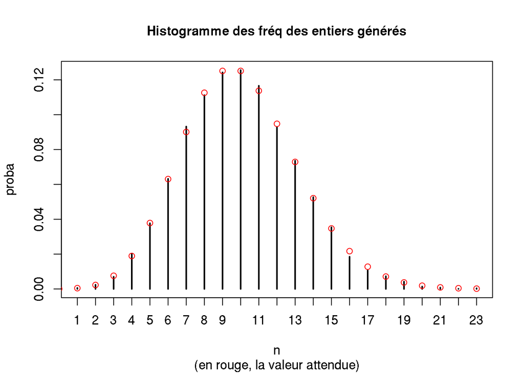

```r
nbPoints = 10000
lambda = 10
nb_tires = my_rpois(nbPoints, lambda)

plot( table(nb_tires)/nbPoints, xlab="n", ylab="proba")
title(main="Histogramme des fréq des entiers générés",
      sub="(en rouge, la valeur attendue)", outer=F)

x_vect = 0:max(nb_tires)
y_vect = dpois( x_vect, lambda )
points(x_vect, y_vect, col="red")
```

##2. Simulation d’une variable discrète quelconque

```r
my_rdiscret_one = function()
{
  support_discret = c(-3, 1.3, 7, 15.2)
  f_rep_discret = cumsum( c(0.1, 0.4, 0.3, 0.2) )
  one_x_unif = runif(1)

  for ( i in 1:length(support_discret) )
  {
    if (one_x_unif < f_rep_discret[i]) { return (support_discret[i]) }
  }
}


my_rdiscret = function (n)
{
  return( replicate(n, my_rdiscret_one()) )
}
```

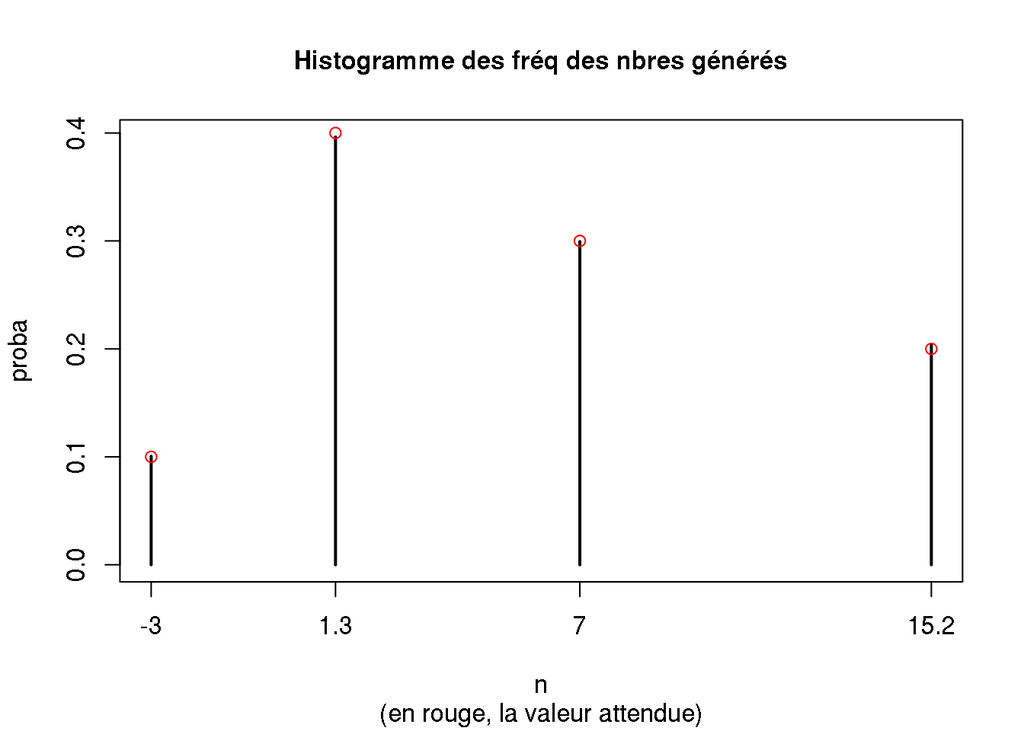

```r
nbPoints = 10000
lambda = 10
nb_tires = my_rdiscret(nbPoints)

plot( table(nb_tires)/nbPoints, xlab="n", ylab="proba")
title(main="Histogramme des fréq des nbres générés",
      sub="(en rouge, la valeur attendue)")

x_vect = c(-3, 1.3, 7, 15.2)
y_vect = c(0.1, 0.4, 0.3, 0.2)
points(x_vect, y_vect, col="red")
```

##3. Méthode de transformation

```r
my_dlaplace = function(scal) { return ( exp(-abs(scal))/2 ) }

my_plaplace = function(scal)
{
  if (scal > 0) { return ( 1-exp(-scal)/2 ) }
  return ( exp(scal)/2 )
}

my_qlaplace = function()
{
  proba = runif(1)
  if (proba < 0.5) { return ( log(2*proba) ) }
  return( -log(2*(1-proba)) )
}

my_rlaplace = function(n)
{
  return( replicate(n, my_qlaplace()) )
}
```

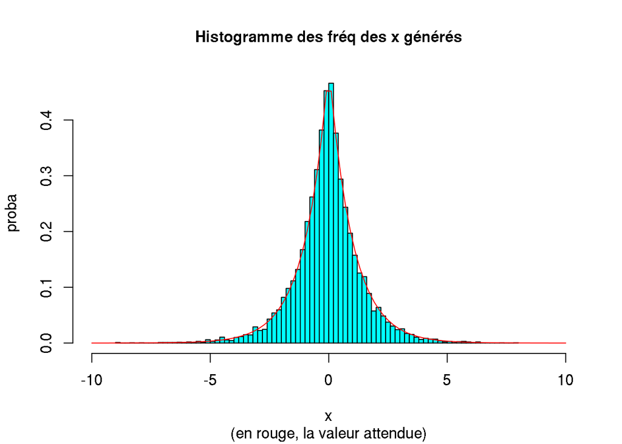

```r
nbPoints = 10000
truehist(my_rlaplace(nbPoints), xlim=c(-10, 10), xlab="x", ylab="proba")
title(main="Histogramme des fréq des x générés",
      sub="(en rouge, la valeur attendue)")

x_vect = seq(-10, 10, len=100)
lines(x_vect, my_dlaplace(x_vect), col="red" )
```

2. On dérive h et on cherche les valeurs de x qui annulent h’(x) => On trouve -1 si x<0 et 1 sinon
3. On détermine les valeurs de h(-1) et h(1), mais comme on a une valeur absolue et un carré: h(1) = h(-1)

h(1) = 2 * exp(1 - 1/2) /sqrt(2pi) = sqrt(2/pi) * exp(1/2)

h(1) = m = sqrt( 2*exp(1)/pi )

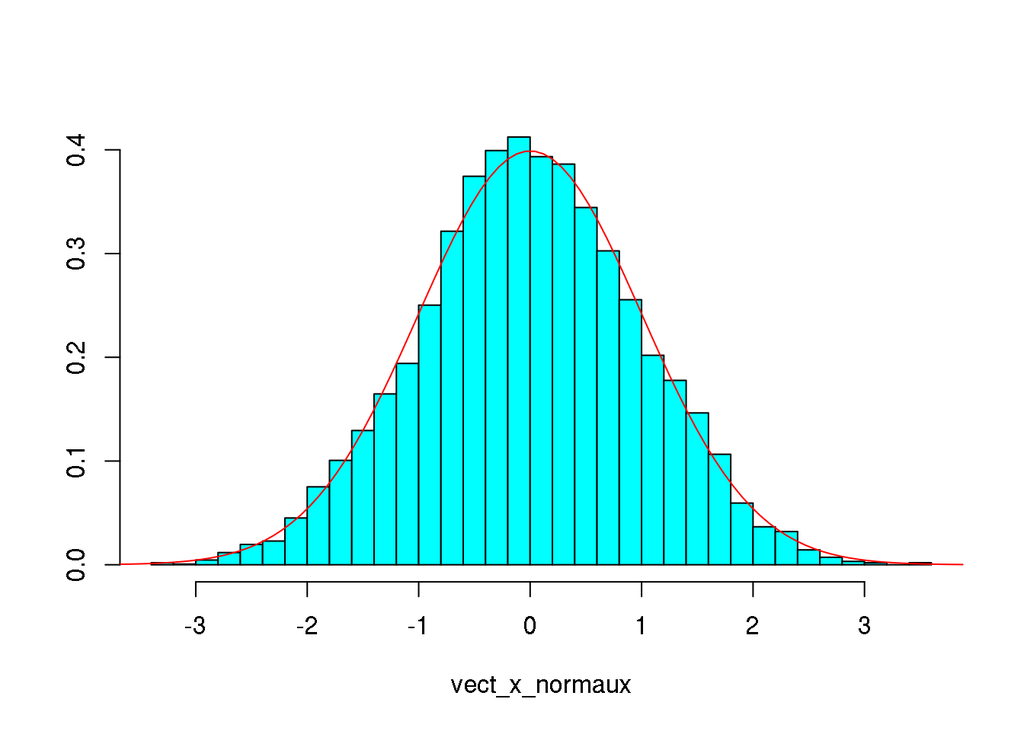

```r
nb_points = 10000
maj = sqrt( 2*exp(1)/pi )

my_rnorm = function(nb_points, maj)
{
  vect_x_i = my_rlaplace(nb_points)
  vect_u_i = runif(nb_points)
  h_i = dnorm(vect_x_i) / my_dlaplace(vect_x_i)
  filtre <- which( vect_u_i <= h_i/maj )
  sum(filtre)
  return ( vect_x_i[filtre] )
}


vect_x_normaux = my_rnorm(nb_points, maj)
truehist(vect_x_normaux)
x_vect = seq(-4, 4, len=100)
lines(x_vect, dnorm(x_vect), col="red" )
```

```r
#Comparaison des taux de rejets prévu et observé:
print( 1 - length(vect_x_normaux)/nb_points)
```

```
## [1] 0.2349
```

```r
print( 1 - 1/maj )
```

```
## [1] 0.2398265
```

##5. Algorithme MCMC:

```r
my_dprop = function(scal, delta) #Ca génère la nouvelle position
{
  start = scal - delta
  end = scal + delta

  return ( runif(1, start, end) )
}

my_rprop = function (n) { return ( replicate(n, dprop()) ) }

my_dtarget = function (scal)
{
  return ( 0.2*dnorm(scal, -3, 2) + 0.5*dnorm(scal) + 0.3*dnorm(scal, 5, 3) )
}

my_rtarget = function (nb_steps)
{
  x_i = 10 #On s'en fout, point de départ
  vect_x_i = c(x_i, rep(0, 100))
  delta = 2

  for( i in 2:(nb_steps+1) )
  {
    y_i = my_dprop(x_i, delta)
    proba_decision = min( 1, my_dtarget(y_i)/my_dtarget(x_i) )
    u_decision = runif(1)

    if (u_decision < proba_decision) {  x_i = y_i }
    vect_x_i[i] = x_i
  }

  return ( vect_x_i )
}
```

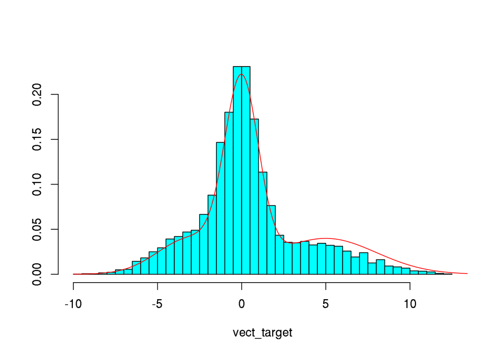

```r
nb_steps = 10000
vect_target = my_rtarget(nb_steps)

truehist( vect_target )

x_vect = seq(-10, 15, len=nb_steps)
lines( x_vect, my_dtarget(x_vect), col="red" )
```

#EXERCICE 4: ##1. MCMC Bayesien

```r
my_rbeta = function(theta) { return ( rbeta(1, 1/(1-theta), 2) ) }

my_dbeta_condition = function (theta, theta_prim)
{
  return ( dbeta(theta, 1/(1-theta_prim), 2) )
}

calc_proba_decision = function (theta, theta_prim)
{
  vraiss_theta = dbinom(70, 100, theta)
  vraiss_theta_prim = dbinom(70, 100, theta_prim)

  numerat = vraiss_theta_prim * my_dbeta_condition(theta, theta_prim)
  denominat = vraiss_theta * my_dbeta_condition(theta_prim, theta)

  return (numerat/denominat)
}

#Comme theta est sur [0;1], pi(theta) = 1 = pi(theta_prim) ??

MCMC_beta_mutation = function (nb_steps)
{
  theta = runif(1)
  vec_theta = c( theta, rep(0, nb_steps) )
  size_ech = 100

  for (i in 2:(nb_steps+1))
  {
    theta_prim = min( 1, my_rbeta(theta) )
    proba_decision = min( 1, calc_proba_decision(theta, theta_prim) )

    if (runif(1) < proba_decision) { theta = theta_prim }
    vec_theta[i] = theta
  }

  return (vec_theta)
}
```

##2. Simulation de la loi conjointe

```r
simul_conjointe = function (nb_points, freq_mut_obs)
{
  vec_theta = rep(0, nb_points)
  compt_pts = 1

  while(compt_pts < nb_points)
  {
    theta = runif(1)
    size_ech = 100
    nb_mut_simul = rbinom(1, size_ech, theta)

    if ( nb_mut_simul == (freq_mut_obs*size_ech) )
    {
      vec_theta[compt_pts] = theta
      compt_pts = compt_pts + 1
    }
  }

  return (vec_theta[1:(compt_pts)])
}

simul_conj_one = function (freq_mut_obs)
{
  #na.omit(replicate(1000000, simul_conj_one)), met 3 secondes de plus que
  #l'autre

  theta = runif(1)
  size_ech = 100

  if ( rbinom(1, size_ech, theta) == (size_ech*freq_mut_obs) )
    return (theta)
  return(NA)
}
```

```r
vec_theta_MCMC = MCMC_beta_mutation(10000)
vec_theta_bourrin = simul_conjointe(10000, 0.7)
```

```r
#Par résolution analytique: pi(theta/x) --> loi bêta (x + 1, n − x + 1)

graphics.off()
par( mfrow=c(1, 2) )
truehist(vec_theta_MCMC, xlim=c(0, 1))
curve(dbeta(x, 70+1, 30+1), from=0, to=1, add=T, xname="x", col="red")
truehist(vec_theta_bourrin, xlim=c(0, 1))
curve(dbeta(x, 70+1, 30+1), from=0, to=1, add=T, xname="x", col="red")
```

[output not shown]

On voit qu’on arrive à **2 distribution équivalentes** avec les 2 méthodes, donc c’est plutôt rassurant.

```r
meanS = paste("Moy MCMC =", mean(vec_theta_MCMC),
              "| Moy bourrin =", mean(vec_theta_bourrin))
varS = paste("Variance MCMC =", var(vec_theta_MCMC),
              "| Variance bourrin =", var(vec_theta_bourrin))
print( paste(meanS, varS, sep='\n') )
```

```
## [1] "Moy MCMC = 0.696136499642849 | Moy bourrin = 0.695732793978834\nVariance MCMC = 0.00219911907303817 | Variance bourrin = 0.00207211310926875"
```

On a des moyennes (environ 0.7, comme prévu) et pareil pour les variances.

##3.

```r
quantile(vec_theta_MCMC, probs=seq(0, 1, 0.025))
```

```
##        0%      2.5%        5%      7.5%       10%     12.5%       15%
## 0.3739939 0.5980225 0.6149761 0.6251328 0.6332820 0.6423919 0.6471445
##     17.5%       20%     22.5%       25%     27.5%       30%     32.5%
## 0.6525510 0.6581648 0.6635272 0.6665593 0.6698943 0.6730182 0.6763270
##       35%     37.5%       40%     42.5%       45%     47.5%       50%
## 0.6811055 0.6834683 0.6868325 0.6895943 0.6925114 0.6960747 0.6982966
##     52.5%       55%     57.5%       60%     62.5%       65%     67.5%
## 0.7018448 0.7045332 0.7082757 0.7107206 0.7128079 0.7150105 0.7180450
##       70%     72.5%       75%     77.5%       80%     82.5%       85%
## 0.7211781 0.7239134 0.7277591 0.7324170 0.7367343 0.7407066 0.7457494
##     87.5%       90%     92.5%       95%     97.5%      100%
## 0.7503074 0.7553410 0.7610857 0.7680246 0.7804874 0.8330025
```

Je suis pas hyper sûr d’avoir bien compris ce que c’est qu’un intervalle de crédibilité. Néanmoins, vvoici une fonction qui devrait déterminer un intervalle de crédibilité centré sur la valeur de theta observée de 0.7.  
Elle prend en argument la valeur de theta observée et un vecteur de valeurs de theta, simulées par une approche bayesienne:

```r
credible_interval = function(theta_obs, vec_theta_bayes, pas)
{
  flag = T
  nb_val_theta = length(vec_theta_bayes)
  i = 1

  while (flag)
  {
    up_born = theta_obs + i * pas
    down_born = theta_obs - i * pas
    nb_inside = sum((vec_theta_bayes > down_born) & (vec_theta_bayes < up_born))

    if ( nb_inside/nb_val_theta > 0.95 )
      flag = F

    i = i + 1
  }

  return ( c(down_born, up_born) )
}
```

Pour la 1ère méthode, avec un pas de 0.001, on arrive à l’intervalle de crédibilité suivant:

```r
credible_interval(0.7, vec_theta_MCMC, 0.001)
```

```
## [1] 0.609 0.791
```

Et pour la 2ème méthode, avec le même pas, on arrive à l’intervalle:

```r
credible_interval(0.7, vec_theta_bourrin, 0.001)
```

```
## [1] 0.611 0.789
```